# practical_exercise_3, Methods 3, 2021, autumn semester

Sille Hasselbalch Markussen

04.10.21

# Exercises and objectives

The objectives of the exercises of this assignment are:  
1) Download and organise the data and model and plot staircase responses based on fits of logistic functions  
2) Fit multilevel models for response times  
3) Fit multilevel models for count data

REMEMBER: In your report, make sure to include code that can reproduce the answers requested in the exercises below (**MAKE A KNITTED VERSION**)  
REMEMBER: This assignment will be part of your final portfolio

## Exercise 1

Go to https://osf.io/ecxsj/files/ and download the files associated with Experiment 2 (there should be 29).  
The data is associated with Experiment 2 of the article at the following DOI https://doi.org/10.1016/j.concog.2019.03.007  
1) Put the data from all subjects into a single data frame

```r
# Making a data frame with the data from experiment 2
lau_files <- list.files(path = "experiment_2",
                    pattern = ".csv",
                    full.names = T)

lau <- data.frame() # Creating empty data frame

for (i in 1:length(lau_files)){
  new_dat <- read.csv(lau_files[i], header = TRUE)
  lau <- rbind(new_dat, lau)
} # Going through each of the files on the list, reading them and them adding them to the data frame
```

2) Describe the data and construct extra variables from the existing variables

i. add a variable to the data frame and call it *correct* (have it be a *logical* variable). Assign a 1 to each row where the subject indicated the correct answer and a 0 to each row where the subject indicated the incorrect answer (**Hint:** the variable *obj.resp* indicates whether the subject answered “even”, *e* or “odd”, *o*, and the variable *target_type* indicates what was actually presented.

```r
lau$target.type[which(lau$target.type=='even')] <- 'e'
lau$target.type[which(lau$target.type=='odd')] <- 'o'

lau$correct <- ifelse((lau$target.type == lau$obj.resp), 1, 0)
```

```
ii. describe what the following variables in the data frame contain, _trial.type_, _pas_, _trial_, _target.contrast_, _cue_, _task_, _target_type_, _rt.subj_, _rt.obj_, _obj.resp_, _subject_ and _correct_. (That means you can ignore the rest of the variables in your description). For each of them, i…
```

**trial.type**: Contains two levels, staircase (practise trials before the experiment) and experiment trials (the actual trials of the experiment). Factor.  
**pas**: Perceptual awareness scale. Subjective rating of the experience of awareness of the stimulus.Ranging from 1 (no experience) to 4 (clear experience). Numeric.  
**trial**: Trial number. Numeric.  
**target.contrast**: Contrast of the target stimulus, relative to the background. Numeric.  
**cue**: Indicator of the cue set. Ranging from 0 to 35. Factor.  
**task**: Three different taks. Stimuli coming from either a set of two (singles), four (pairs) or eight (quadruplet) stimuli. Factor.  
**target.type**: Whether the target numbers are even or odd. Factor.  
**rt.subject**: Reaction time of the subjective rating. Numeric.  
**rt.obj**: Reaction time (ms) of the task.Numeric.  
**obj.resp**: The participant’s answer to the task. Even or odd. Factor.  
**subject**: Number identifying the participant. Factor.  
**correct**: Whether the participant answered correctly. 1 indicates correct answers and 0 indicates wrong answers. Factor.

```r
# changing class of the nessecary variables.
lau$trial.type <- as.factor(lau$trial.type)
lau$target.contrast <- as.numeric(lau$target.contrast)
lau$cue <- as.factor(lau$cue)
lau$task <- as.factor(lau$task)
lau$target.type <- as.factor(lau$target.type)
lau$rt.obj <- as.numeric(lau$rt.obj)
lau$rt.subj <- as.numeric(lau$rt.subj)
lau$obj.resp <- as.factor(lau$obj.resp)
lau$subject <- as.factor(lau$subject)
lau$correct <- as.factor(lau$correct)
```

```
iii. for the staircasing part __only__, create a plot for each subject where you plot the estimated function (on the _target.contrast_ range from 0-1) based on the fitted values of a model (use `glm`) that models _correct_ as dependent on _target.contrast_. These plots will be our _no-pooling_ model…
```

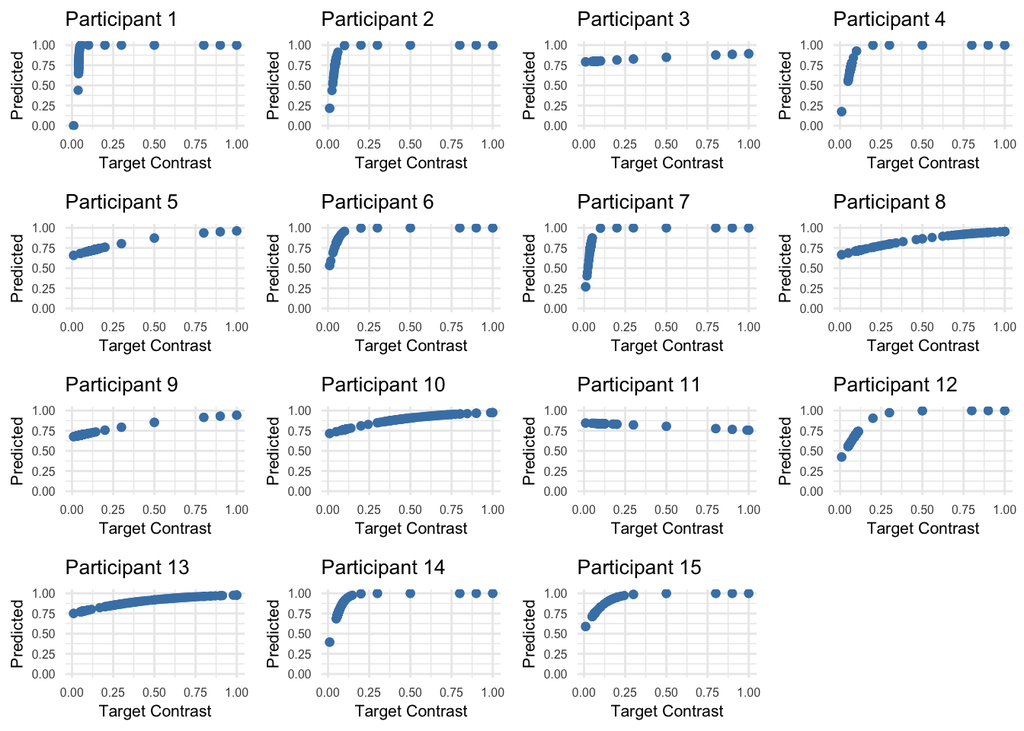

```r
# New df only containing staircase
staircase <- lau %>%
  filter(lau$trial.type == 'staircase')

# Making a function to run a model for each participant
nopoolfun <- function(i){
  dat <- staircase[which(staircase$subject == i),]
  model <- glm(correct ~ target.contrast, family = 'binomial', data = dat)
  fitted <- model$fitted.values
  plot_dat <- data.frame(cbind(fitted, 'target.contrast' = dat$target.contrast))

  plot <- ggplot(plot_dat, aes(x = target.contrast, y = fitted))+
    geom_point(colour = "steelblue") +
    xlab('Target Contrast') +
    ylab('Predicted') +
    ylim(c(0,1))+
    ggtitle(paste0('Participant ', as.character(i))) +
    theme_minimal() +
    theme(plot.title = element_text(size = 10), axis.title=element_text(size = 8), axis.text=element_text(size=6))

  return(plot)
}

# Running the function for every participant
for (participant in 1:29){
  nopoolfun(participant)
}

subjects <- c(1:15)

plots <- lapply(subjects, FUN=nopoolfun)
do.call(grid.arrange,  plots)
```

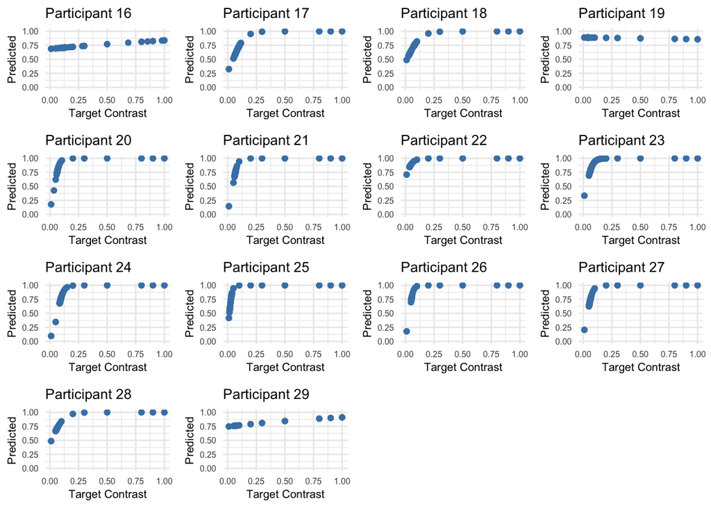

```
iv. on top of those plots, add the estimated functions (on the _target.contrast_ range from 0-1) for each subject based on partial pooling model (use `glmer` from the package `lme4`) where unique intercepts and slopes for _target.contrast_ are modelled for each _subject_
```

```r
subjects <- c(16:29)

plots <- lapply(subjects, FUN=nopoolfun)
require(gridExtra)
do.call(grid.arrange,  plots)
```

```r
# Building the partial pooling model
model <- glmer(correct ~ target.contrast + (1 + target.contrast | subject), family = 'binomial', data = staircase)
```

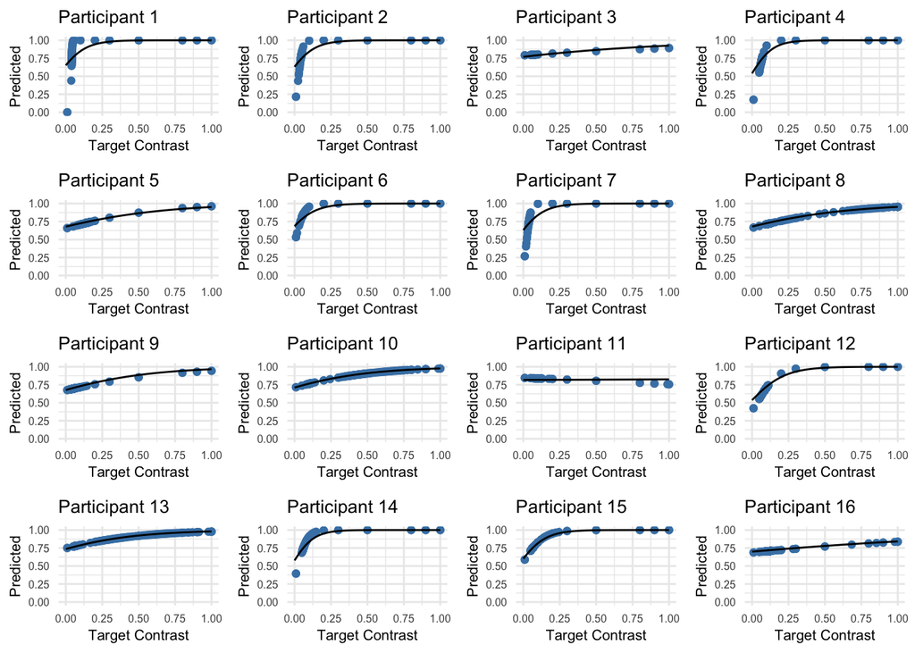

```r
# Making function to run a model for each participant and plotting the estimated functions for each participant
partialpoolfun <- function(i){
  # new df for each participant
  dat <- staircase[which(staircase$subject == i),]
  # model for each participant
  model1 <- glm(correct ~ target.contrast, family = 'binomial', data = dat)
  # extracting fitted values from the model from each participant
  fitted <- model1$fitted.values
  # new df containing the fitted values and target contrast
  plot_dat <- data.frame(cbind(fitted, 'target.contrast' = dat$target.contrast))

  # another new df containing hypothetical target contrast values and subject number
  newdf<- data.frame(cbind(seq(0, 1, by = 0.01),rep(i)))
  colnames(newdf) <- c('target.contrast', 'subject')

  # adding the predicted values for the hypothetical target contrast values
  newdf$predictmod <- predict(model, type = 'response', newdata = newdf)

  # plotting
  plot <- ggplot(plot_dat, aes(x = target.contrast, y = fitted))+
    geom_point(colour = "steelblue") +
    geom_line(data = newdf, aes(x = target.contrast, y = predictmod)) +
    xlab('Target Contrast') +
    ylab('Predicted') +
    ylim(c(0,1))+
    ggtitle(paste0('Participant ', as.character(i))) +
    theme_minimal() +
    theme(plot.title = element_text(size = 10), axis.title=element_text(size = 8), axis.text=element_text(size=6))

  return(plot)
}

subjects <- c(1:16)
plots <- lapply(subjects, FUN=partialpoolfun)
do.call(grid.arrange,  plots)
```

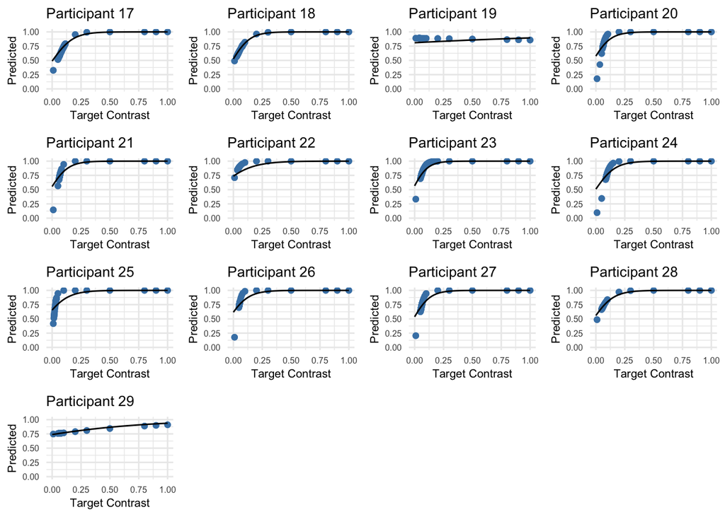

```
v. in your own words, describe how the partial pooling model allows for a better fit for each subject
```

```r
subjects <- c(17:29)
plots <- lapply(subjects, FUN=partialpoolfun)
do.call(grid.arrange,  plots)
```

Compared to no pooling, partial pooling provides a more generalisable fit. Since ‘no pooling’ models estimate fitted values based on data for one participant per model the resulting models are really only generalisable to that participant. Contrary, partial pooling models takes individual differences into account when estimating values fitted to all participants. Also compared to complete pooling, partitial pooling provides a better fit for the data. Since all subjects are modelled together, the complete pooling models tedns to overlook important underlying information in the data, such as individual differences.

## Exercise 2

Now we **only** look at the *experiment* trials (*trial.type*)

```r
# data frame only containing experimental trials
lau_exp <- lau %>%
  filter(trial.type=="experiment")
```

1. Pick four subjects and plot their Quantile-Quantile (Q-Q) plots for the residuals of their objective response times (*rt.obj*) based on a model where only intercept is modelled

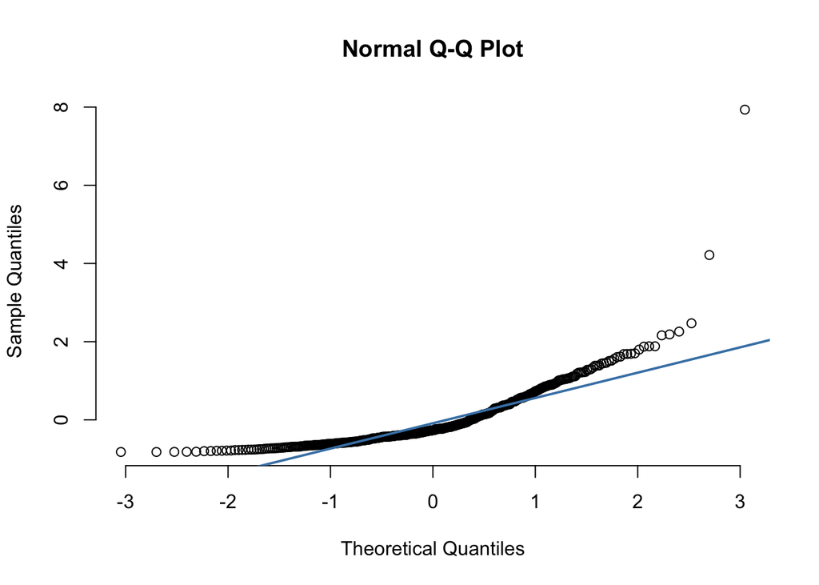

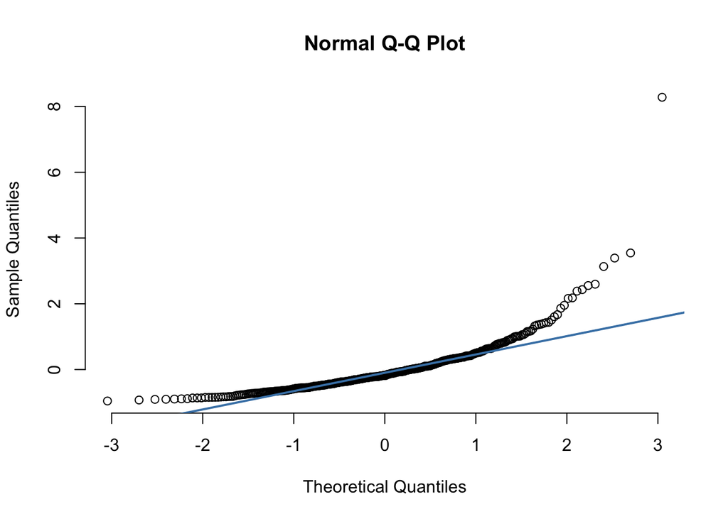

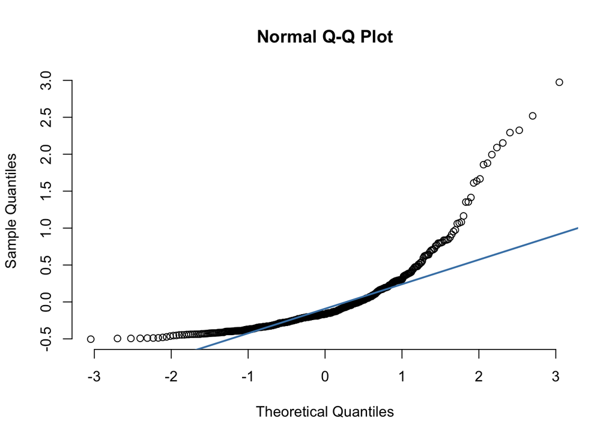

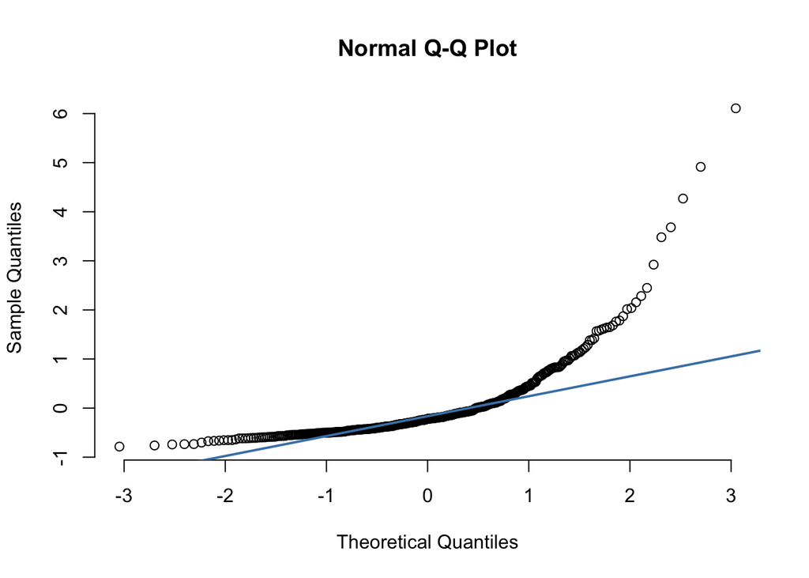

```
i. comment on these
```

```r
exp4 <- lau_exp %>% filter(subject == '3' | subject == '7' | subject == '17' | subject == '28')
exp4$subject <- as.numeric(exp4$subject)

qqfun <- function(i){
  interceptmodel <- lm(rt.obj ~ 1, data = exp4, subset = subject == i)
  qqnorm(resid(interceptmodel), pch = 1, frame = FALSE)
  qqline(resid(interceptmodel), col = "steelblue", lwd = 2)
}



subjects <- c(3,7,17,28)
lapply(subjects, qqfun)
```

They do not seem to fulfill the assumption of normality. They all look right skewed - some more than others.

ii. does a log-transformation of the response time data improve the Q-Q-plots?

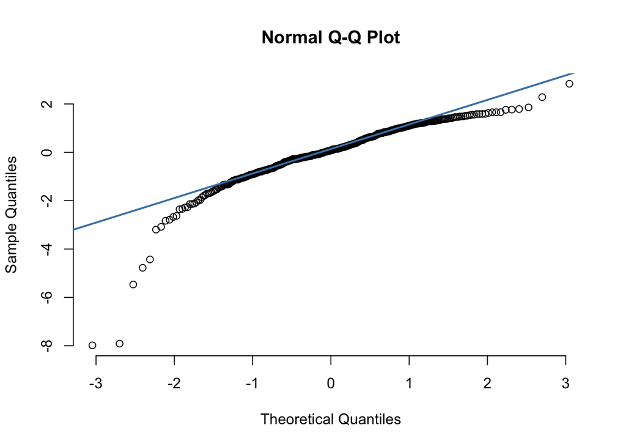

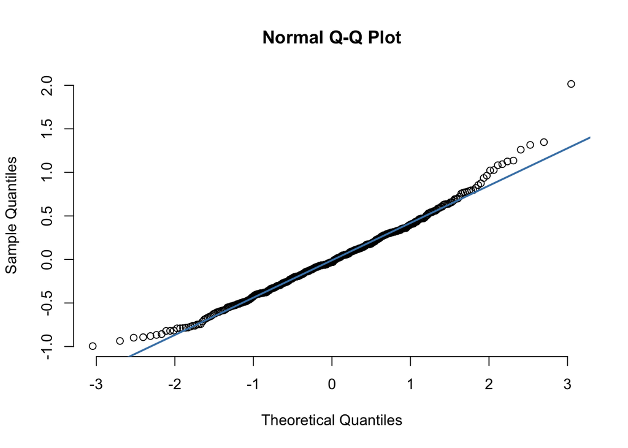

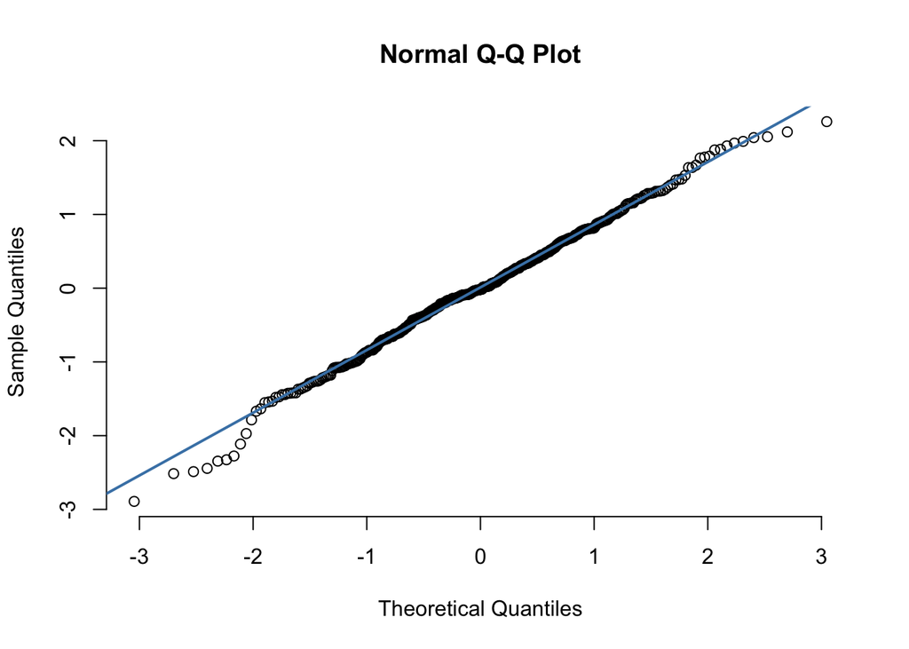

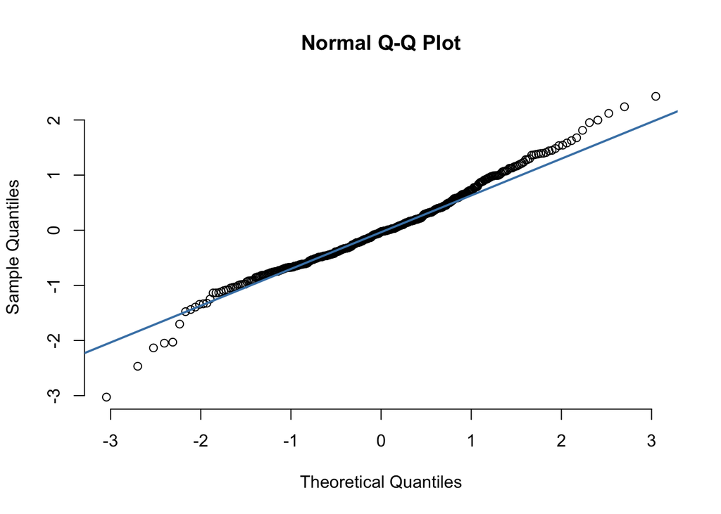

```r
qqfunlog <- function(i){
  interceptmodel <- lm(log(rt.obj) ~ 1, data = exp4, subset = subject == i)
  qqnorm(resid(interceptmodel), pch = 1, frame = FALSE)
  qqline(resid(interceptmodel), col = "steelblue", lwd = 2)
}

lapply(subjects, qqfunlog)
```

The log-transformation seem to improve the qq-plots. However, the qq-plot for participant 3 now seems to be left skewed.

2. Now do a partial pooling model modelling objective response times as dependent on *task*? (set `REML=FALSE` in your `lmer`-specification)

i. which would you include among your random effects and why? (support your choices with relevant measures, taking into account variance explained and number of parameters going into the modelling)

```r
m1 <- lmer(log(rt.obj) ~ task + (1|subject), lau_exp, REML = F)
m2 <- lmer(log(rt.obj) ~ task + (1|subject) + (1|trial), lau_exp, REML = F)
m3 <- lmer(log(rt.obj) ~ task + (1|trial), lau_exp, REML = F)
m4 <- lmer(log(rt.obj) ~ task + (1+task|subject), lau_exp, REML = F)
m5 <- lmer(log(rt.obj) ~ task + (1+task|subject) + (1|trial), lau_exp, REML = F)

model_text <- c("model 1", "model 2", "model 3", "model 4", "model 5")
sigmas <- c(sigma(m1),sigma(m2),sigma(m3), sigma(m4), sigma(m5))
AIC <- c(AIC(m1), AIC(m2), AIC(m3), AIC(m4), AIC(m5))
mtable <- as_tibble(cbind(model_text,sigmas,AIC))
mtable
```

```
## # A tibble: 5 × 3
##   model_text sigmas            AIC
##   <chr>      <chr>             <chr>
## 1 model 1    0.786510836267907 29685.3126188652
## 2 model 2    0.767353686772583 29459.9382110624
## 3 model 3    0.877443929266087 32560.1503149819
## 4 model 4    0.780526761806287 29560.3359953566
## 5 model 5    0.761030007720908 29327.6815811547
```

The fifth model including task as random slope for subject as random intercept and trial as random intercept explains the most variance, indicated by the lowest residual standard deviation of the five models. Further, it has the lowest AIC of the models.

ii. explain in your own words what your chosen models says about response times between the different tasks

```r
summary(m5)
```

```
## Linear mixed model fit by maximum likelihood  ['lmerMod']
## Formula: log(rt.obj) ~ task + (1 + task | subject) + (1 | trial)
##    Data: lau_exp
##
##      AIC      BIC   logLik deviance df.resid
##  29327.7  29409.5 -14652.8  29305.7    12517
##
## Scaled residuals:
##      Min       1Q   Median       3Q      Max
## -10.5363  -0.4958  -0.0279   0.5119   8.0799
##
## Random effects:
##  Groups   Name           Variance Std.Dev. Corr
##  trial    (Intercept)    0.02995  0.17307
##  subject  (Intercept)    0.14918  0.38623
##           taskquadruplet 0.00400  0.06325   0.35
##           tasksingles    0.03227  0.17964   0.38 -0.58
##  Residual                0.57917  0.76103
## Number of obs: 12528, groups:  trial, 432; subject, 29
##
## Fixed effects:
##                Estimate Std. Error t value
## (Intercept)    -0.26407    0.07317  -3.609
## taskquadruplet -0.07225    0.02054  -3.518
## tasksingles    -0.17868    0.03739  -4.778
##
## Correlation of Fixed Effects:
##             (Intr) tskqdr
## taskqudrplt  0.099
## tasksingles  0.279 -0.114
```

Both for the quadruplet and the singles tasks reaction times are shorter than the pair task. This is indicated by the negative slopes of quadruplet and singles in relation to pairs as the intercept. Relative to the quadruplet task the reaction time of the singles task is faster.

3. Now add *pas* and its interaction with *task* to the fixed effects

```r
m_pas <- lm(log(rt.obj) ~ task*pas, lau_exp, REML = F)
```

i. how many types of group intercepts (random effects) can you add without ending up with convergence issues or singular fits?

```r
ma <- lmer(log(rt.obj) ~ task + (1|subject) + (1|trial) + (1|cue), lau_exp, REML = F)
mb <- lmer(log(rt.obj) ~ task + (1|subject) + (1|trial) + (1|cue) + (1|target.contrast), lau_exp, REML = F)
```

```
## boundary (singular) fit: see ?isSingular
```

```r
mc <- lmer(log(rt.obj) ~ task + (1|subject) + (1|trial) + (1|cue) + (1|target.contrast) + (1|target.type), lau_exp, REML = F)
```

Adding four types of group intercepts ( *subject*, *trial*, *cue* & *target.contrast* ) resulted in a singular fit. When adding a fourth type of group intercept ( *target.type* ) the model failed to converge.

```
ii. create a model by adding random intercepts (without modelling slopes) that results in a singular fit - then use `print(VarCorr(<your.model>), comp='Variance')` to inspect the variance vector - explain why the fit is singular (Hint: read the first paragraph under details in the help for `isSingular`)
```

```r
mb <- lmer(log(rt.obj) ~ task + (1|subject) + (1|trial) + (1|cue) + (1|target.contrast), lau_exp, REML = F)
```

```
## boundary (singular) fit: see ?isSingular
```

```r
print(VarCorr(mb), comp='Variance')
```

```
##  Groups          Name        Variance
##  trial           (Intercept) 2.9323e-02
##  cue             (Intercept) 4.4012e-03
##  target.contrast (Intercept) 3.5429e-10
##  subject         (Intercept) 1.7531e-01
##  Residual                    5.8634e-01
```

The model with four types of group intercepts from the previous point ( *i* ) resulted in a singular fit. Inspecting the variance vector it is visible that the variance of *target.contrast* as a random intercept is close to zero, meaning that it is near singular. This indicates that it is not adding additional explanation of the data. This can result in over fitting, thus, adding more variables is not advantageous.

```
iii. in your own words - how could you explain why your model would result in a singular fit?
```

The explanation for the singular fit of the model might be that some of the variables are explaining the same variance, thus, not carrying much explanatory power into the model.

## Exercise 3

1. Initialise a new data frame, `data.count`. *count* should indicate the number of times they categorized their experience as *pas* 1-4 for each *task*. I.e. the data frame would have for subject 1: for task:singles, pas1 was used # times, pas2 was used # times, pas3 was used # times and pas4 was used # times. You would then do the same for task:pairs and task:quadruplet

```r
lau_count <- lau_exp %>%
  group_by(subject, pas, task) %>%
  summarise(count=n())
lau_count$pas <- as.factor(lau_count$pas)
```

2. Now fit a multilevel model that models a unique “slope” for *pas* for each *subject* with the interaction between *pas* and *task* and their main effects being modelled

```r
multi_model <- glmer(count ~ pas*task + (1 + pas|subject), family = "poisson", data = lau_count, glmerControl(optimizer="bobyqa"))
```

```
i. which family should be used?
```

The poisson family since we are dealing with count data with residuals belonging to a poisson distribution.

```
ii. why is a slope for _pas_ not really being modelled?
```

If you look at pas as a fixed effect on its own, it does not make much sense; it does not make sense to use the ratings of pas to predict count. We are interested in the interaction between pas and task, since we can only use pas to say something in relation to task.

```
iii. if you get a convergence error, try another algorithm (the default is the _Nelder_Mead_) - try (_bobyqa_) for which the `dfoptim` package is needed. In `glmer`, you can add the following for the `control` argument: `glmerControl(optimizer="bobyqa")` (if you are interested, also have a look at the function `allFit`)
```

```
iv. when you have a converging fit - fit a model with only the main effects of _pas_ and _task_. Compare this with the model that also includes the interaction
```

```r
 multi_model2 <- glmer(count ~ pas+task + (1 + pas|subject), family = "poisson", data = lau_count, glmerControl(optimizer="bobyqa"))

AIC(multi_model, multi_model2)
```

```
##              df      AIC
## multi_model  22 2778.987
## multi_model2 16 2933.264
```

Comparing the AIC of the two models it seems like the interaction model is best with the lowest AIC despite being the most complex model.

```
v. indicate which of the two models, you would choose and why
```

It makes sense to include the interaction of pas and task since the levels of task mostly makes sense in relation to the level of tasks. It is expected that the distribution of ratings is influenced by the task, thus, it is necessary to add the interaction to model this effect. Further, as indicated by the AICs it seems that the interaction model is the best model.

```
vi. based on your chosen model - write a short report on what this says about the distribution of ratings as dependent on _pas_ and _task_
```

```r
summary(multi_model)
```

```
## Generalized linear mixed model fit by maximum likelihood (Laplace
##   Approximation) [glmerMod]
##  Family: poisson  ( log )
## Formula: count ~ pas * task + (1 + pas | subject)
##    Data: lau_count
## Control: glmerControl(optimizer = "bobyqa")
##
##      AIC      BIC   logLik deviance df.resid
##   2779.0   2861.8  -1367.5   2735.0      297
##
## Scaled residuals:
##     Min      1Q  Median      3Q     Max
## -4.2797 -0.8249 -0.0760  0.7367  6.4498
##
## Random effects:
##  Groups  Name        Variance Std.Dev. Corr
##  subject (Intercept) 0.5628   0.7502
##          pas2        0.6562   0.8101   -0.73
##          pas3        1.1803   1.0864   -0.91  0.80
##          pas4        3.8601   1.9647   -0.91  0.50  0.80
## Number of obs: 319, groups:  subject, 29
##
## Fixed effects:
##                     Estimate Std. Error z value Pr(>|z|)
## (Intercept)          3.61415    0.14254  25.355  < 2e-16 ***
## pas2                -0.04098    0.15647  -0.262 0.793418
## pas3                -0.37077    0.20907  -1.773 0.076164 .
## pas4                -0.94171    0.37739  -2.495 0.012585 *
## taskquadruplet       0.06071    0.03732   1.627 0.103762
## tasksingles         -0.23490    0.04031  -5.828 5.62e-09 ***
## pas2:taskquadruplet -0.04411    0.05520  -0.799 0.424197
## pas3:taskquadruplet -0.11069    0.06365  -1.739 0.082015 .
## pas4:taskquadruplet -0.11778    0.06279  -1.876 0.060665 .
## pas2:tasksingles     0.17454    0.05783   3.018 0.002543 **
## pas3:tasksingles     0.23754    0.06457   3.679 0.000234 ***
## pas4:tasksingles     0.59798    0.06098   9.807  < 2e-16 ***
## ---
## Signif. codes:  0 '***' 0.001 '**' 0.01 '*' 0.05 '.' 0.1 ' ' 1
##
## Correlation of Fixed Effects:
```

[output cut: 9 more lines]

```
## ps2:tsksngl  0.087 -0.171 -0.059 -0.033 -0.332 -0.697  0.486    0.195
## ps3:tsksngl  0.078 -0.071 -0.151 -0.030 -0.298 -0.624  0.201    0.485
## ps4:tsksngl  0.082 -0.075 -0.056 -0.085 -0.315 -0.661  0.213    0.185
##             ps4:tskq ps2:tsks ps3:tsks
## pas2
## pas3
## pas4
## taskqudrplt
## tasksingles
## ps2:tskqdrp
## ps3:tskqdrp
## ps4:tskqdrp
## ps2:tsksngl  0.198
## ps3:tsksngl  0.177    0.435
## ps4:tsksngl  0.509    0.461    0.413
```

```r
# extracting estimates
model_text <- c("Intercept", "Quadruplet", "Singles")
estimates <- c(multi_model@beta[1], multi_model@beta[5], multi_model@beta[6])
estimatesExp <- c(exp(multi_model@beta[1]), exp(multi_model@beta[5]), exp(multi_model@beta[6]))
tasktable <- as_tibble(cbind(model_text,estimates,estimatesExp))
tasktable
```

```
## # A tibble: 3 × 3
##   model_text estimates          estimatesExp
##   <chr>      <chr>              <chr>
## 1 Intercept  3.61414675437776   37.1196602221413
## 2 Quadruplet 0.0607086477095806 1.06258928126238
## 3 Singles    -0.234903744627158 0.7906469499831
```

```r
model_text <- c("Pas 2, quadruplet", "Pas 3, quadruplet", "Pas 4, quadruplet","Pas 2, singles", "Pas 3, singles", "Pas 4, singles")
estimates <- c(multi_model@beta[7], multi_model@beta[8], multi_model@beta[9], multi_model@beta[10], multi_model@beta[11], multi_model@beta[12])
estimatesExp <- c(exp(multi_model@beta[7]), exp(multi_model@beta[8]), exp(multi_model@beta[9]), exp(multi_model@beta[10]), exp(multi_model@beta[11]), exp(multi_model@beta[12]))
interactiontable <- as_tibble(cbind(model_text,estimates,estimatesExp))
interactiontable
```

```
## # A tibble: 6 × 3
##   model_text        estimates          estimatesExp
##   <chr>             <chr>              <chr>
## 1 Pas 2, quadruplet -0.044110412632432 0.95684830350036
## 2 Pas 3, quadruplet -0.110691997510834 0.895214434745132
## 3 Pas 4, quadruplet -0.117784926708673 0.88888720795511
## 4 Pas 2, singles    0.174541036125271  1.19069960308055
## 5 Pas 3, singles    0.237540984928311  1.2681269698186
## 6 Pas 4, singles    0.597975351136592  1.8184333817306
```

vii. include a plot that shows the estimated amount of ratings for four subjects of your choosing

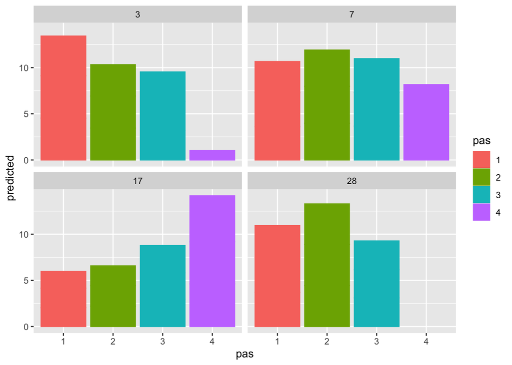

```r
count4 <- lau_count %>% filter(subject == '3' | subject == '7' | subject == '17' | subject == '28')
count4$predicted <- predict(multi_model, newdata=count4)
ggplot(count4, aes(y = predicted, x = pas, colour=pas, fill=pas)) +
  geom_bar(stat = 'identity') +
  facet_wrap(~ subject)
```

3. Finally, fit a multilevel model that models *correct* as dependent on *task* with a unique intercept for each *subject*

```r
m1 <- glmer(correct ~ task + (1 | subject), data = lau_exp, family = 'binomial')
```

```
i. does _task_ explain performance?
```

```r
summary(m1)
```

```
## Generalized linear mixed model fit by maximum likelihood (Laplace
##   Approximation) [glmerMod]
##  Family: binomial  ( logit )
## Formula: correct ~ task + (1 | subject)
##    Data: lau_exp
##
##      AIC      BIC   logLik deviance df.resid
##  13636.3  13666.0  -6814.1  13628.3    12524
##
## Scaled residuals:
##     Min      1Q  Median      3Q     Max
## -3.7450 -1.0599  0.4791  0.6483  0.9795
##
## Random effects:
##  Groups  Name        Variance Std.Dev.
##  subject (Intercept) 0.3622   0.6018
## Number of obs: 12528, groups:  subject, 29
##
## Fixed effects:
##                Estimate Std. Error z value Pr(>|z|)
## (Intercept)     1.11896    0.11765   9.511  < 2e-16 ***
## taskquadruplet -0.07496    0.05081  -1.475  0.14015
## tasksingles     0.16603    0.05218   3.182  0.00146 **
## ---
## Signif. codes:  0 '***' 0.001 '**' 0.01 '*' 0.05 '.' 0.1 ' ' 1
##
## Correlation of Fixed Effects:
##             (Intr) tskqdr
## taskqudrplt -0.219
## tasksingles -0.213  0.494
```

Since the singles task is significantly predicting performance it has some explanatory power.

```
ii. add _pas_ as a main effect on top of _task_ - what are the consequences of that?
```

```r
m2 <- glmer(correct ~ task + pas + (1 | subject), family = "binomial", data = lau_exp)
summary(m2)
```

```
## Generalized linear mixed model fit by maximum likelihood (Laplace
##   Approximation) [glmerMod]
##  Family: binomial  ( logit )
## Formula: correct ~ task + pas + (1 | subject)
##    Data: lau_exp
##
##      AIC      BIC   logLik deviance df.resid
##  12258.2  12295.4  -6124.1  12248.2    12523
##
## Scaled residuals:
##     Min      1Q  Median      3Q     Max
## -5.7622 -0.7280  0.3227  0.5954  1.6353
##
## Random effects:
##  Groups  Name        Variance Std.Dev.
##  subject (Intercept) 0.2424   0.4923
## Number of obs: 12528, groups:  subject, 29
##
## Fixed effects:
##                Estimate Std. Error z value Pr(>|z|)
## (Intercept)    -0.81547    0.11197  -7.283 3.26e-13 ***
## taskquadruplet -0.02633    0.05371  -0.490    0.624
## tasksingles    -0.03492    0.05568  -0.627    0.531
## pas             0.94641    0.02787  33.952  < 2e-16 ***
## ---
## Signif. codes:  0 '***' 0.001 '**' 0.01 '*' 0.05 '.' 0.1 ' ' 1
##
## Correlation of Fixed Effects:
##             (Intr) tskqdr tsksng
## taskqudrplt -0.252
## tasksingles -0.190  0.488
## pas         -0.461  0.020 -0.095
```

Pas is significantly predicting performance, however, neither of the task are no longer significant.

```
iii. now fit a multilevel model that models _correct_ as dependent on _pas_ with a unique intercept for each _subject_
```

```r
m3 <- glmer(correct ~ pas + (1 | subject), family = "binomial", data = lau_exp)
```

```
iv. finally, fit a model that models the interaction between _task_ and _pas_  and their main effects
```

```r
m4 <- glmer(correct ~ task*pas + (1 | subject), family = "binomial", data = lau_exp)
```

```
v. describe in your words which model is the best in explaining the variance in accuracy
```

```r
accuracyfun <- function(model, data) {
  predicted <- predict(model, data, type='response')
  predicted <- ifelse(predicted > 0.5, 1, 0)
  tab <-  table(data$correct, predicted)
  accuracy <- (tab[1,1] + tab[2,2])/(tab[1,1] + tab[2,2] +tab[1,2] + tab[2,1])

  return(accuracy)
}

accuracyfun(m4, lau_exp)
```

```
## [1] 0.7409004
```

```r
accuracyfun(m2, lau_exp)
```

```
## [1] 0.7421775
```

```r
accuracyfun(m3, lau_exp)
```

```
## [1] 0.7421775
```

Evaluating the accuracy of the classifications of correct/not correct for the three models, it is visible that their performance is the same, predicting correctness with 74% accuracy.

## Exercise 1

Go to https://osf.io/ecxsj/files/ and download the files associated with Experiment 2 (there should be 29).  
The data is associated with Experiment 2 of the article at the following DOI https://doi.org/10.1016/j.concog.2019.03.007

1. Put the data from all subjects into a single data frame
2. Describe the data and construct extra variables from the existing variables
   1. add a variable to the data frame and call it *correct* (have it be a *logical* variable). Assign a 1 to each row where the subject indicated the correct answer and a 0 to each row where the subject indicated the incorrect answer (**Hint:** the variable *obj.resp* indicates whether the subject answered “even”, *e* or “odd”, *o*, and the variable *target_type* indicates what was actually presented.
   2. describe what the following variables in the data frame contain, *trial.type*, *pas*, *trial*, *target.contrast*, *cue*, *task*, *target_type*, *rt.subj*, *rt.obj*, *obj.resp*, *subject* and *correct*. (That means you can ignore the rest of the variables in your description). For each of them, indicate and argue for what `class` they should be classified into, e.g. *factor*, *numeric* etc.
   3. for the staircasing part **only**, create a plot for each subject where you plot the estimated function (on the *target.contrast* range from 0-1) based on the fitted values of a model (use `glm`) that models *correct* as dependent on *target.contrast*. These plots will be our *no-pooling* model. Comment on the fits - do we have enough data to plot the logistic functions?
   4. on top of those plots, add the estimated functions (on the *target.contrast* range from 0-1) for each subject based on partial pooling model (use `glmer` from the package `lme4`) where unique intercepts and slopes for *target.contrast* are modelled for each *subject*
   5. in your own words, describe how the partial pooling model allows for a better fit for each subject

## Exercise 2

Now we **only** look at the *experiment* trials (*trial.type*)

1. Pick four subjects and plot their Quantile-Quantile (Q-Q) plots for the residuals of their objective response times (*rt.obj*) based on a model where only intercept is modelled
   1. comment on these
   2. does a log-transformation of the response time data improve the Q-Q-plots?
2. Now do a partial pooling model modelling objective response times as dependent on *task*? (set `REML=FALSE` in your `lmer`-specification)
   1. which would you include among your random effects and why? (support your choices with relevant measures, taking into account variance explained and number of parameters going into the modelling)
   2. explain in your own words what your chosen models says about response times between the different tasks
3. Now add *pas* and its interaction with *task* to the fixed effects
   1. how many types of group intercepts (random effects) can you add without ending up with convergence issues or singular fits?
   2. create a model by adding random intercepts (without modelling slopes) that results in a singular fit - then use `print(VarCorr(<your.model>), comp='Variance')` to inspect the variance vector - explain why the fit is singular (Hint: read the first paragraph under details in the help for `isSingular`)
   3. in your own words - how could you explain why your model would result in a singular fit?

## Exercise 3

1. Initialise a new data frame, `data.count`. *count* should indicate the number of times they categorized their experience as *pas* 1-4 for each *task*. I.e. the data frame would have for subject 1: for task:singles, pas1 was used # times, pas2 was used # times, pas3 was used # times and pas4 was used # times. You would then do the same for task:pairs and task:quadruplet

```r
## you can start from this if you want to, but you can also make your own from scratch
data.count <- data.frame(count = numeric(),
                         pas = numeric(), ## remember to make this into a factor afterwards
                         task = numeric(), ## and this too
                         subject = numeric()) ## and this too
```

2. Now fit a multilevel model that models a unique “slope” for *pas* for each *subject* with the interaction between *pas* and *task* and their main effects being modelled
   1. which family should be used?
   2. why is a slope for *pas* not really being modelled?
   3. if you get a convergence error, try another algorithm (the default is the *Nelder_Mead*) - try (*bobyqa*) for which the `dfoptim` package is needed. In `glmer`, you can add the following for the `control` argument: `glmerControl(optimizer="bobyqa")` (if you are interested, also have a look at the function `allFit`)
   4. when you have a converging fit - fit a model with only the main effects of *pas* and *task*. Compare this with the model that also includes the interaction
   5. indicate which of the two models, you would choose and why
   6. based on your chosen model - write a short report on what this says about the distribution of ratings as dependent on *pas* and *task*
   7. include a plot that shows the estimated amount of ratings for four subjects of your choosing
3. Finally, fit a multilevel model that models *correct* as dependent on *task* with a unique intercept for each *subject*
   1. does *task* explain performance?
   2. add *pas* as a main effect on top of *task* - what are the consequences of that?
   3. now fit a multilevel model that models *correct* as dependent on *pas* with a unique intercept for each *subject*
   4. finally, fit a model that models the interaction between *task* and *pas* and their main effects
   5. describe in your words which model is the best in explaining the variance in accuracy